# Writing and Applying Functions - Text Strings

Richard Upton  
5 August 2015

### Functions

- Functions are a key element of R
- Functions take an input, process it and return an output
- The function output can be assigned to another object
- R has base functions and functions from installed packages
- Writing your own functions unleashes the power of R!

### Using Functions

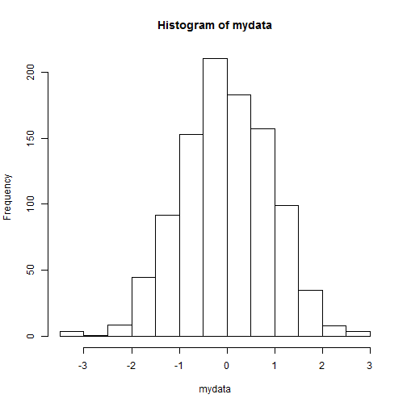

```r
> mydata <- rnorm(1000)
> hist(mydata)
```

### Using Functions

Are there arguments for **hist** that give us more control?

[figure not shown]

### Using Functions

Arguments to functions can be supplied by name or by order

Try to limit using order when more than 1 argument

The first argument of **hist** is “x”, the data  
The second argument is “breaks”

This argument can have multiple formats

- A text string giving the cell method
- A number giving the number of cells

There is also an argument “main” for a plot title

Functions can have default values for arguments

### Function arguments by order

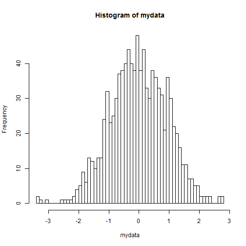

```r
> hist(mydata, 50)
```

### Function arguments by name

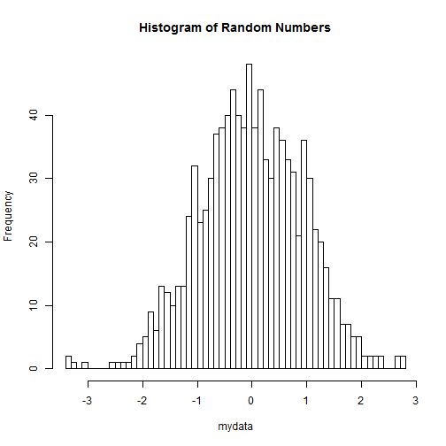

```r
> hist(x=mydata, breaks=50, main="Histogram of Random Numbers")
```

### Writing Functions

Functions in R take the following format:

```r
  addtwo <- function(x) {
     y <- x+2
     y }
```

- x is the function argument - the input to the function
- all the calculations take place between the curly brackets
- objects outside a function can be used in the function “environment”
- objects assigned inside a function are local to the function “environment”
- y is the output (result of the last line of function)

### Testing the function

```r
  test <- c(2,3,4)
  result <- addtwo(test)

  result
```

```
[1] 4 5 6
```

### Global and local variables

```r
  addtwo <- function(x) {
     y <- x+2
     y }
```

```r
  test <- c(2,3,4)
  result <- addtwo(test)

  #y
```

y is not found in the global environment; it's local to addtwo

### Default argument values

```r
  addnum <- function(x, num=4) {
     y <- x+num
     y }
```

Unless a value for *num* is given, it will default to 4

```r
  test <- c(2,3,4)
  result <- addnum(test)
  result
```

```
[1] 6 7 8
```

```r
  result <- addnum(test, num=6)
  result
```

```
[1]  8  9 10
```

[figure not shown]

### Applying Functions

Often, we need to *apply* a function by a factor:

- Mean of data by Treatment group
- Maximum concentration by Subject
- Percent of baseline by Subject
- AUC by Treatment and Age
- Summarising demographic data

### Applying Functions

We have some options:  
The **apply** family of functions in the base  
Effective but a little cluncky

The **doBy** package:  
Easy syntax list outputs may need further processing

The **plyr** and **dplyr** packages  
Easy syntax (but different to doBy)  
Returns dataframes, lists and more

### Applying Functions - Example data

```r
> exampledata <- read.csv("data_apply.csv")
> exampledata
```

```
   ID DOSE AUC
1   1    5  34
2   1    5  42
3   1   10  60
4   1   10  58
5   2    5  43
6   2    5  35
7   2   10  74
8   2   10  65
9   3    5  28
10  3    5  27
11  3   10  51
12  3   10  49
```

### Applying Functions - the doBy package

```r
> library(doBy)
> summarydata <- summaryBy(AUC~ID, data=exampledata, FUN=mean)
> summarydata
```

```
  ID AUC.mean
1  1    48.50
2  2    54.25
3  3    38.75
```

### Applying Functions - the doBy package

```r
> library(doBy)
> summarydata <- summaryBy(AUC~DOSE, data=exampledata, FUN=mean)
> summarydata
```

```
  DOSE AUC.mean
1    5    34.83
2   10    59.50
```

### Applying Functions - the doBy package

```r
> library(doBy)
> summarydata <- summaryBy(AUC~ID+DOSE, data=exampledata, FUN=mean)
> summarydata
```

```
  ID DOSE AUC.mean
1  1    5     38.0
2  1   10     59.0
3  2    5     39.0
4  2   10     69.5
5  3    5     27.5
6  3   10     50.0
```

[figure not shown]

### Text Strings

Text is delineated by quotes: “my text string”  
Text makes an object of class *character*  
Text strings are important in R as:

- object names
- working directory paths
- file names
- data

R has a number of tools for manipulating text strings

### Paste to join text strings

```r
  string1 <- "PhaseI"
  string2 <- "Control"
  filename <- paste(string1,string2,".csv", sep="")
  filename
```

```
[1] "PhaseIControl.csv"
```

```r
  write.csv(exampledata, file=filename)
```

the *sep* argument defaults to a single space.  
It's set to “no space” here.

### Text matching in R

There are a number of R methods for manipulating text  
Many are based on pattern matching using “regular” expressions  
**regex** are a common standard in many computing systems  
**regex** are a compact, powerful and confusing instructions for text matching  
See ?regex for an introduction  
See ?glob2rx for a Windows wildcard format  
**gsub** will get the basics done

### gsub to edit text strings

First argument is old text  
Second argument is new text

```r
  filename
```

```
[1] "PhaseIControl.csv"
```

```r
  filename2 <- gsub("PhaseI","PhaseIaVolunteer",filename)
  filename2
```

```
[1] "PhaseIaVolunteerControl.csv"
```

### Splitting text strings

We have some options:

The **strsplit** function in the base package  
Effective but a little cluncky

The **stringr** package (Hadley Wickham again)  
Handy for splitting strings into columns  
This is a common task in pharmacometrics

### String splitting

```r
> library(stringr)
> exampledata <- read.csv("data_string.csv")
> exampledata
```

```
    TIME CONC
1 10_min 0.56
2 30_min 0.92
3 1_hour 0.42
4 4_hour 0.61
```

### String splitting

The TIME column is split into 2 columns at “_”

```r
> newcols <- str_split_fixed(exampledata$TIME,"_",2)
> exampledata$TIMEnumber <- as.numeric(newcols[,1])
> exampledata$TIMEtext <- newcols[,2]
> exampledata
```

```
    TIME CONC TIMEnumber TIMEtext
1 10_min 0.56         10      min
2 30_min 0.92         30      min
3 1_hour 0.42          1     hour
4 4_hour 0.61          4     hour
```

[figure not shown]